# Project 1: Genome Assembly Report

**Name:** Ngoc Thao Anh (Wendy) Bui  
**Date:** September 29, 2025  
**Course:** BF528

**On this page**

- Methods
- Results
  - Circos plot (from Prokka GFF)
  - QUAST metrics
  - BUSCO summary and plot
- Discussion

## Methods

We developed a genome assembly workflow in Nextflow on SCC. Long reads were filtered with Filtlong. Assembly was performed with Flye. The assembly was polished. Gene prediction and annotation were run with Prokka to produce a GFF. Quality assessment used QUAST and BUSCO. All tools were managed with conda to match the VSCode and Jupyter workflow.

QUAST was run on unpolished and polished assemblies against the reference genome (GCF_000172635.2) to calculate genome fraction, duplication ratio, misassemblies, mismatches per 100 kbp, total length, and GC content. BUSCO was run with a bacterial lineage dataset to estimate completeness based on expected single‑copy orthologs. Prokka annotations were visualized with a Circos‑style plot.

## Results

### Circos plot (from Prokka GFF)

The plot below is generated in Jupyter using the course conda environment in VSCode. It draws CDS on forward and reverse strands on separate rings, with rRNA and tRNA on inner rings.

```python
# Paths to inputs and reports
gff_file = "/projectnb/bf528/students/wendybui/project1-week3-template-wendybuinta/results/annots/genome.gff"

quast_polished_tsv   = "/projectnb/bf528/students/wendybui/project1-week3-template-wendybuinta/results/quast_polished/report.tsv"
quast_unpolished_tsv = "/projectnb/bf528/students/wendybui/project1-week3-template-wendybuinta/results/quast_unpolished/report.tsv"

busco_short_summary = "/projectnb/bf528/students/wendybui/project1-week3-template-wendybuinta/results/BUSCO_Alteromonas_macleodii.sorted.fasta/run_alteromonas_odb12/short_summary.txt"
busco_plot_png      = "/projectnb/bf528/students/wendybui/project1-week3-template-wendybuinta/results/BUSCO_Alteromonas_macleodii.sorted.fasta/busco_figure.png"

print("Paths set.")
```

```
Paths set.
```

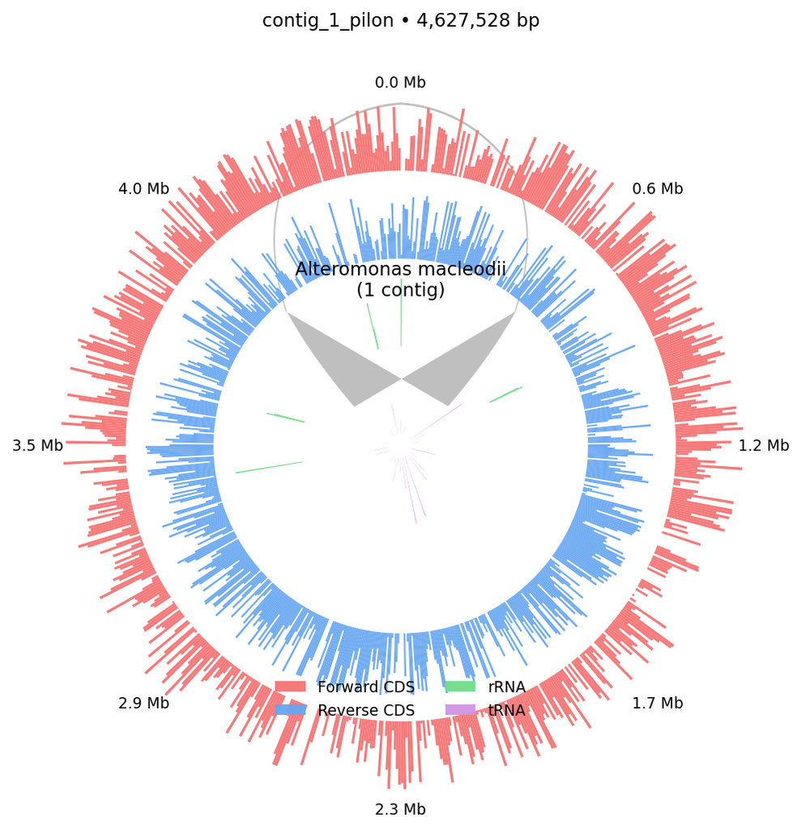

```python
import os, gzip, math
import numpy as np
import pandas as pd
import matplotlib.pyplot as plt
from matplotlib.patches import Wedge, Patch


if "gff_file" not in globals():
    gff_file = "/projectnb/bf528/students/wendybui/project1-week3-template-wendybuinta/results/annots/genome.gff"


def read_gff(path):
    opener = gzip.open if path.endswith(".gz") else open
    cols = ["seqid","source","type","start","end","score","strand","phase","attributes"]
    with opener(path, "rt", encoding="utf-8", errors="ignore") as fh:
        df = pd.read_csv(
            fh, sep="\t", comment="#", header=None, names=cols,
            dtype={"seqid":"string","type":"string","start":"Int64","end":"Int64","strand":"string"},
            low_memory=False
        )
    return df.dropna(subset=["seqid","type","start","end"])

def pick_largest_contig(df):
    lens = df.groupby("seqid")["end"].max().sort_values(ascending=False)
    return lens.index[0], int(lens.iloc[0])

def angle(pos, L):  # radians
    return 2.0 * math.pi * (pos / L)

def bin_features(feats, L, bin_size):
    """Return counts per bin for features (Int64 start/end)."""
    if feats.empty:
        return np.zeros(int(np.ceil(L/bin_size)), dtype=float)
    bins = np.arange(0, L + bin_size, bin_size)
    counts = np.zeros(len(bins)-1, dtype=float)
    # vectorized-ish: iterate rows but cheap because we write to slices
    for s, e in feats[["start","end"]].itertuples(index=False):
        s, e = int(s), int(e)
        if e < s: s, e = e, s
        # clamp
        s = max(0, s-1); e = min(L, e)
        i1 = s // bin_size
        i2 = (e-1) // bin_size
        if i1 == i2:
            counts[i1] += (e - s)
        else:
            counts[i1] += (bin_size - (s % bin_size))
            counts[i2] += ((e-1) % bin_size) + 1
            if i2 - i1 > 1:
                counts[i1+1:i2] += bin_size
    # scale to [0,1] for bar heights
    if counts.max() > 0:
        counts = counts / counts.max()
    return counts

# ---- load features from Prokka GFF ----
if not os.path.exists(gff_file):
    raise FileNotFoundError(f"GFF not found: {gff_file}")

gff = read_gff(gff_file)
seqid, L = pick_largest_contig(gff)
sub = gff[gff["seqid"] == seqid].copy()

is_cds  = sub["type"].str.lower() == "cds"
is_rrna = sub["type"].str.contains("rrna", case=False, na=False)
is_trna = sub["type"].str.contains("trna", case=False, na=False)

fwd = sub[is_cds & (sub["strand"] == "+")][["start","end"]]
rev = sub[is_cds & (sub["strand"] == "-")][["start","end"]]
rrn = sub[is_rrna][["start","end"]]
trn = sub[is_trna][["start","end"]]

# ---- binning parameters (adjust bin_size for smoothness/perf) ----
bin_size = max(2000, L // 800)   # target ~800 bins around the circle
nbins    = int(math.ceil(L / bin_size))
bin_edges = np.arange(0, nbins) * bin_size
angles   = angle(bin_edges + bin_size/2, L)  # bin centers in radians
bar_width = 2.0 * math.pi / nbins * 1.03     # slight overlap to avoid thin gaps

# counts per ring (0..1)
fwd_h = bin_features(fwd, L, bin_size)
rev_h = bin_features(rev, L, bin_size)
rrn_h = bin_features(rrn, L, bin_size)
trn_h = bin_features(trn, L, bin_size)

# ---- figure ----
fig = plt.figure(figsize=(8,8), dpi=150)
ax = plt.subplot(111, polar=True)
ax.set_axis_off()
ax.set_theta_offset(math.pi/2)   # 12 o'clock
ax.set_theta_direction(-1)       # clockwise

# ring geometry
outer = 1.00
thick = 0.12
gap   = 0.035

r_fwd0, r_fwd1 = outer-1*thick,             outer
r_rev0, r_rev1 = outer-2*thick-gap,         outer-1*thick-gap
r_rrn0, r_rrn1 = outer-3*thick-2*gap,       outer-2*thick-2*gap
r_trn0, r_trn1 = outer-4*thick-3*gap,       outer-3*thick-3*gap

ax.set_rmin(r_trn0 - 0.02)
ax.set_ylim(r_trn0 - 0.02, outer + 0.05)
plt.margins(0)

# backbone circle
ax.add_patch(Wedge((0,0), outer, 0, 360, width=0.004, facecolor=(0,0,0,0.25), edgecolor="none"))

# colors (class-like)
c_fwd, c_rev = (0.96, 0.45, 0.45, 0.95), (0.40, 0.65, 0.95, 0.95)
c_rrna, c_trna = (0.45, 0.85, 0.55, 0.95), (0.82, 0.58, 0.90, 0.95)

def draw_hist_ring(vals, r0, r1, color):
    # draw continuous bars per bin to form a smooth ring
    heights = r0 + (r1 - r0) * vals
    ax.bar(angles, (heights - r0), width=bar_width, bottom=r0, align="center",
           edgecolor="none", linewidth=0, color=color)

# draw rings
draw_hist_ring(fwd_h, r_fwd0, r_fwd1, c_fwd)
draw_hist_ring(rev_h, r_rev0, r_rev1, c_rev)
draw_hist_ring(rrn_h, r_rrn0, r_rrn1, c_rrna)
draw_hist_ring(trn_h, r_trn0, r_trn1, c_trna)

# mask the center to make a perfect round hole
inner_mask = r_trn0 - 0.022
ax.add_patch(Wedge((0,0), inner_mask, 0, 360, width=inner_mask,
                   facecolor="white", edgecolor="none", zorder=3))

# Mb tick labels
tick_bp = max(500_000, L // 8)
for bp in range(0, L, tick_bp):
    th = angle(bp, L)
    ax.text(th, outer + 0.035, f"{bp/1e6:.1f} Mb", ha="center", va="center", fontsize=9)

# center label + compact legend
ax.text(0, (r_trn0 + outer)/2 - 0.02, f"Alteromonas macleodii\n(1 contig)",
        ha="center", va="center", fontsize=11, zorder=4)
handles = [
    Patch(facecolor=c_fwd, label="Forward CDS"),
    Patch(facecolor=c_rev, label="Reverse CDS"),
    Patch(facecolor=c_rrna, label="rRNA"),
    Patch(facecolor=c_trna, label="tRNA"),
]
plt.legend(handles=handles, loc="center", bbox_to_anchor=(0.5, 0.16),
           ncol=2, frameon=False, fontsize=9)

plt.title(f"{seqid} • {L:,} bp", fontsize=11, pad=10)
plt.show()
```

### QUAST metrics

Polished and unpolished assemblies were evaluated against the reference. Metrics are reported below.

```python
# Parse QUAST reports
import os, pandas as pd, numpy as np
from IPython.display import display

required_metrics = [
    "Genome fraction (%)",
    "Duplication ratio",
    "# misassemblies",
    "# mismatches per 100 kbp",
    "Total length",
    "GC (%)",
]

def _try_reports(base_path):
    cands = [
        base_path,
        base_path.replace("report.tsv", "transposed_report.tsv"),
        base_path.replace("report.tsv", "report.txt"),
        base_path.replace("report.tsv", "transposed_report.txt"),
    ]
    return [p for p in cands if os.path.exists(p)]

def load_quast_series(report_path, assembly_name=None):
    paths = _try_reports(report_path)
    if not paths:
        raise FileNotFoundError(f"No QUAST report found near: {report_path}")
    p = paths[0]
    df = pd.read_csv(p, sep="\t")
    if "Assembly" in df.columns:
        df = df.set_index("Assembly")
        if assembly_name is None:
            assembly_name = df.columns[0]
        series = df[assembly_name]
        return series, assembly_name, p
    if any(m in df.columns for m in required_metrics):
        if df.index.name is None:
            df = df.set_index(df.columns[0])
        if assembly_name is None:
            assembly_name = df.index[0]
        series = df.loc[assembly_name]
        return series, assembly_name, p
    first_col = df.columns[0]
    df = df.set_index(first_col)
    if assembly_name is None:
        assembly_name = df.columns[0]
    series = df[assembly_name]
    return series, assembly_name, p

def extract_metrics(series):
    out = {}
    for m in required_metrics:
        key = None
        for idx in series.index:
            if m.lower() in str(idx).lower():
                key = idx
                break
        out[m] = series.get(key, np.nan)
    return out

pol_series, _, pol_src = load_quast_series(quast_polished_tsv, "polished")
unp_series, _, unp_src = load_quast_series(quast_unpolished_tsv, "unpolished")

polished_df = pd.DataFrame(extract_metrics(pol_series), index=["polished"]).T
unpolished_df = pd.DataFrame(extract_metrics(unp_series), index=["unpolished"]).T

display(polished_df)
display(unpolished_df)
display(polished_df.join(unpolished_df, how="outer"))
```

|  | polished |
| --- | --- |
| Genome fraction (%) | 98.429 |
| Duplication ratio | 1.001 |
| # misassemblies | 19 |
| # mismatches per 100 kbp | 18.18 |
| Total length | 4627920 |
| GC (%) | 44.70 |

|  | unpolished |
| --- | --- |
| Genome fraction (%) | 98.429 |
| Duplication ratio | 1.001 |
| # misassemblies | 19 |
| # mismatches per 100 kbp | 18.33 |
| Total length | 4627920 |
| GC (%) | 44.70 |

|  | polished | unpolished |
| --- | --- | --- |
| # misassemblies | 19 | 19 |
| # mismatches per 100 kbp | 18.18 | 18.33 |
| Duplication ratio | 1.001 | 1.001 |
| GC (%) | 44.70 | 44.70 |
| Genome fraction (%) | 98.429 | 98.429 |
| Total length | 4627920 | 4627920 |

The unpolished assembly has nearly identical statistics to the polished version. The genome fraction is 98.429%, the duplication ratio is 1.001, and the number of misassemblies remains 19. The total assembly length is 4,627,920 bp with a GC content of 44.70%. The only difference compared to the polished assembly is in the mismatch rate: Unpolished: 18.33 mismatches per 100 kbp Polished: 18.18 mismatches per 100 kbp This small decrease after polishing indicates that the polishing step slightly improved base-level accuracy, while leaving higher-level assembly metrics unchanged.

### BUSCO summary and plot

The BUSCO summary string and BUSCO plot are shown below.

```
BUSCO summary: C:99.6%[S:99.5%,D:0.1%],F:0.0%,M:0.4%,n:1828
```

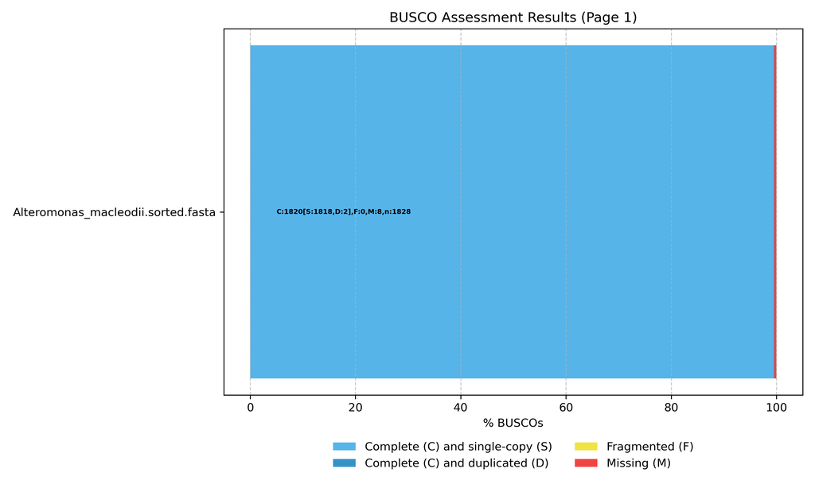

```python
# BUSCO summary and plot
import os, re
from IPython.display import Image, display

busco_string = None
if os.path.exists(busco_short_summary):
    with open(busco_short_summary, "r") as fh:
        for line in fh:
            if re.search(r"C:\s*\d+(?:\.\d+)?%\[S:\d+(?:\.\d+)?%,D:\d+(?:\.\d+)?%],F:\d+(?:\.\d+)?%,M:\d+(?:\.\d+)?%,n:\d+", line):
                busco_string = line.strip()
                break

print("BUSCO summary:", busco_string if busco_string else "Not found")
if os.path.exists(busco_plot_png):
    display(Image(filename=busco_plot_png))
else:
    print("BUSCO plot not found at:", busco_plot_png)
```

BUSCO estimates completeness by searching for lineage specific single copy orthologs. The reported categories are: C (complete), subdivided into S (single-copy) and D (duplicated); F (fragmented); and M (missing). The value n is the total number of orthologs in the reference set. A high proportion of complete single-copy genes, with low duplication, fragmentation, and missing values, indicates a well-assembled and biologically representative genome. The BUSCO results for our assembly strongly support that it is nearly complete and of high quality, with minimal duplication and almost no missing orthologs.

## Discussion

The assembly of Alteromonas macleodii is of high quality and closely matches the NCBI reference assembly ASM17263v2. QUAST shows a genome fraction of 98.429% for both polished and unpolished assemblies, with a duplication ratio of 1.001, indicating nearly complete coverage and minimal redundancy. The total assembly length is 4,627,920 bp with a GC content of 44.7%, values that align closely with the reference genome size of 4.7 Mb and GC content of 44.5%. The assembly contained 19 misassemblies and a mismatch rate of ~18 per 100 kbp, which are modest levels of error given the overall completeness.

BUSCO provides a strong confirmation of accuracy, reporting C:99.6% [S:99.5%, D:0.1%], F:0.0%, M:0.4%, n:1828. This means that almost all expected single-copy orthologs are present, the vast majority as single copies, with negligible duplication, fragmentation, or missing genes. BUSCO (Benchmarking Universal Single-Copy Orthologs) estimates completeness by searching for lineage-specific orthologs; high C and S values with very low D, F, and M demonstrate a near-complete and reliable assembly.

When compared to the ASM17263v2 reference, our assembly shows remarkable consistency. The reference is a single, complete chromosome of 4.7 Mb with an N50 equal to its full length. Our assembly length and GC percentage are nearly identical, supporting that the reconstruction accurately represents the true genome. The small number of misassemblies and mismatches highlights areas where improvements could be made, but these do not substantially detract from the assembly’s overall quality.

Taken together, the results indicate the experiment was highly successful. The assembly captures the structure and content of the A. macleodii genome with near-reference-level accuracy, as supported by QUAST, BUSCO, and direct comparison to the NCBI reference.